# Mise en oeuvre réseau de la caméra IP

## Adressage IP par DHCP

Pour communiquer avec la caméra IP, il faut que celle-ci possède une adresse IP dans le réseau local.

On distingue deux situations pour assigner une adresse IP à un équipement :

- de manière statique : l’adresse est fixe et configurée le plus souvent manuellement puis stockée dans la configuration de son système d’exploitation.
- de manière dynamique : l’adresse est automatiquement transmise et assignée grâce au protocole DHCP (*Dynamic Host Configuration Protocol*) ou BOOTP.

Dans notre situation, l’adresse IP de la caméra est assignée par un serveur DHCP.

```
Il vous faut connaître l'adresse MAC de votre caméra.
```

```
Une adresse MAC (Media Access Control address) est un identifiant physique stocké dans une carte réseau ou une interface réseau et utilisé pour attribuer mondialement une adresse unique (codé sur 48 bits). L'adresse MAC est utilisée dans les trames transmises. Une trame transporte un paquet. L'adresse MAC identifie donc de manière unique l'interface physique de communication. Par exemple, on aura donc une adresse MAC pour l'interface Ethernet et une autre pour l'interface Wifi.
```

Pour cette partie, vous allez avoir besoin d’un analyseur de protocoles. Lancer wireshark en mode root.

```
$ gksudo wireshark &
```

Ou :

[figure not shown]

On va capturer le traffic en filtrant celui en provenance de l’adresse MAC de la caméra :

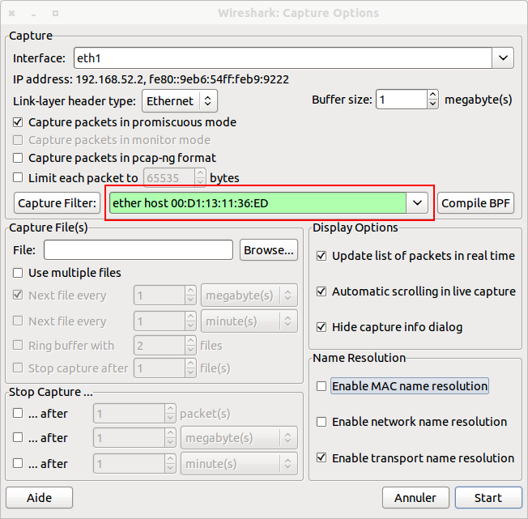

```
Si vous êtes relié à un switch, vous ne pourrez seulement capturer le traffic émis par la caméra en broadcast. En effet, le switch se comporte comme un filtre au niveau des adresses MAC.
```

On démarre la capture puis on allume la caméra :

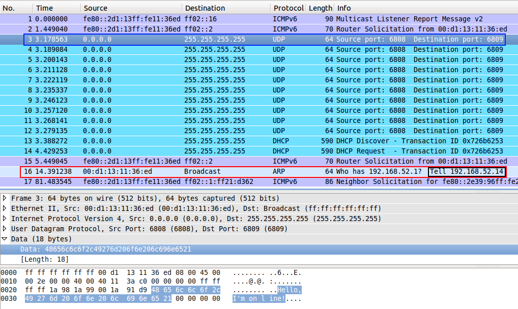

On observe essentiellement :

- l’envoi de datagrammes UDP en broadcast IP contenant le message “Hello, I’m online!”
- une requête ARP de l’adresse IP ici 192.168.52.14 qui est donc celle de la caméra

Pour vérifier, on va se connecter au serveur DHCP puis rechercher l’adresse IP attribuée à partir de l’adresse MAC de la caméra :

```
$ ssh toto@192.168.52.83

# cat /var/lib/dhcp/dhcpd.leases | grep -A 1 -B 5 -i "00:D1:13:11:36:ED"
lease 192.168.52.216 {
  starts 3 2015/09/09 13:09:31;
  ends 3 2015/09/09 21:09:31;
  tstp 3 2015/09/09 21:09:31;
  binding state free;
  hardware ethernet 00:d1:13:11:36:ed;
  uid "\001\000\321\023\0216\355";
--
lease 192.168.52.216 {
  starts 5 2015/09/25 06:06:29;
  ends 5 2015/09/25 14:06:29;
  binding state active;
  next binding state free;
  hardware ethernet 00:d1:13:11:36:ed;
  uid "\001\000\321\023\0216\355";
```

```
SSH (Secure Shell) est à la fois un programme informatique et un protocole de communication sécurisé. Le protocole de connexion impose un échange de clés de chiffrement en début de connexion. Le protocole SSH a été conçu avec l'objectif de remplacer les différents programmes rlogin, telnet, rcp, ftp et rsh.
```

Maintenant, on va vérifier l’état de la communication IP avec la caméra :

```
$ ping 192.168.52.216 -c 1
PING 192.168.52.216 (192.168.52.216) 56(84) bytes of data.
64 bytes from 192.168.52.216: icmp_req=1 ttl=64 time=0.432 ms

--- 192.168.52.216 ping statistics ---
1 packets transmitted, 1 received, 0% packet loss, time 0ms
rtt min/avg/max/mdev = 0.432/0.432/0.432/0.000 ms
```

```
ping est le nom d'une commande informatique réseau permettant d'envoyer une requête ICMP (demande d'ECHO ou echo-request) d'une machine à une autre machine (qui retourne une réponse d'ECHO ou echo-reply). Selon la réponse on connaît l'état de la machine distante. Si la machine ne répond pas il se peut que l'on ne puisse tout simplement pas communiquer avec elle. Cette commande réseau de base permet donc d'obtenir des informations et en particulier le temps de réponse de la machine à travers le réseau et aussi quel est l'état de la connexion avec cette machine (renvoi d'un code d'erreur correspondant).
```

## Services disponibles

La caméra IP fournit un certain nombre de services. Pour les découvrir, il suffit de “scanner” les ports ouverts sur la caméra. En effet, pour accéder à un service distant (notion de serveur offrant un service), il faut pouvoir l’identifier et cela est réalisé par le numéro de port. On peut remarquer que l’adresse IP ne permet que d’identifier la “machine” avec laquelle on communique mais cela ne suffira pas pour identifier l’application avec laquelle on veut communiquer.

Pour trouver les numéros de port “ouvert”, on va utiliser l’outil `nmap` côté client :

```
$ sudo apt-get install nmap

$ nmap -A -T4 192.168.52.216

Starting Nmap 5.21 ( http://nmap.org ) at 2015-09-25 08:28 CEST
Nmap scan report for 192.168.52.216
Host is up (0.015s latency).
Not shown: 997 closed ports
PORT     STATE SERVICE    VERSION
23/tcp   open  telnet     BusyBox telnetd
99/tcp   open  http       GoAhead httpd (WAP http config)
| http-auth: HTTP Service requires authentication
|_  Auth type: Digest, realm = GoAhead
|_html-title: Document Error: Unauthorized
8600/tcp open  tcpwrapped
Service Info: Device: WAP

Service detection performed. Please report any incorrect results at http://nmap.org/submit/ .
Nmap done: 1 IP address (1 host up) scanned in 11.40 seconds

$ nmap -p 21-23 192.168.52.216

Starting Nmap 5.21 ( http://nmap.org ) at 2015-09-25 08:34 CEST
Nmap scan report for 192.168.52.216
Host is up (0.00071s latency).
PORT   STATE  SERVICE
21/tcp closed ftp
22/tcp closed ssh
23/tcp open   telnet

Nmap done: 1 IP address (1 host up) scanned in 0.03 seconds
```

On en conclut que :

- un serveur HTTP s’exécute sur le port 99 (et pas 80, le port par défaut pour les serveurs web)
- un serveur telnet s’exécute sur son port par défaut le 23

```
Telnet (TErminal NETwork ou TELecommunication NETwork, ou encore TELetype NETwork) est un protocole utilisé sur tout réseau TCP/IP, permettant de communiquer avec un serveur distant en échangeant des lignes de textes et en recevant des réponses également sous forme de texte. Créé en 1969, telnet est un moyen de communication très généraliste et bi-directionnel. Il appartient à la couche application du modèle OSI et du modèle ARPA (DoD). Il est normalisé par l'IETF (RFC 15, 854 et 855). Il était notamment utilisé pour administrer des serveurs UNIX distant ou de l'équipement réseau, avant de tomber en désuétude par défaut de sécurisation, le texte étant échangé en clair, et l'adoption de SSH.
```

On peut vérifier le port affecté au service `telnet` dans la liste des ports *well-known* (bien connus) :

```
$ cat /etc/services | grep telnet
telnet      23/tcp
...
```

## Accès web : test en ligne de commande

Il est possible de tester l’accès aux CGI du serveur web de la caméra en ligne de commandes.

```
CGI (Common Gateway Interface) est une interface utilisée par les serveurs HTTP. Elle a été normalisée par la RFC 3875. Au lieu d'envoyer le contenu d'un fichier (fichier HTML, image), le serveur HTTP exécute un programme, puis retourne le contenu généré. CGI est le standard industriel qui indique comment transmettre la requête du serveur HTTP au programme, et comment récupérer la réponse générée. Une des caractéristiques de l'interface CGI est d'être indépendante de tout langage de programmation, car elle utilise les flux standard et les variables d'environnement. Même si le langage Perl a historiquement été souvent utilisé pour en écrire, il est possible d'écrire un programme CGI en C, Python, PHP, script shell, en VB ou en tout autre langage de programmation.
```

On va capturer le traffic en filtrant celui en provenance de l’adresse IP de la caméra :

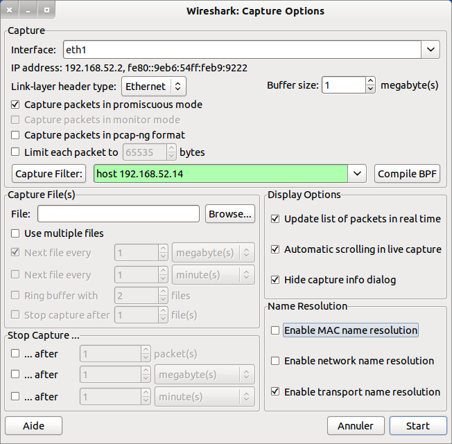

On démarre la capture puis on exécute une requête :

```
$ curl -v -X GET 'http://192.168.52.14:99/get_params.cgi?user=admin&pwd='
* About to connect() to 192.168.52.14 port 99 (#0)
*   Trying 192.168.52.14... connected
> GET /get_params.cgi?user=admin&pwd= HTTP/1.1
> User-Agent: curl/7.22.0 (x86_64-pc-linux-gnu) libcurl/7.22.0
> Host: 192.168.52.14:99
> Accept: */*
>
< HTTP/1.1 200 OK
< Date: Mon Sep 28 16:43:42 2015
< Server: GoAhead-Webs
< Last-modified: Mon Mar  2 20:56:00 1970
< Content-type: text/html
< Cache-Control:no-cache
< Content-length: 3331
< Connection: close
<
var now1=1443458622;
var tz=-28800;
var ntp_enable=1;
var ntp_svr="time.nist.gov";
var dhcpen=1;
var ip="192.168.52.14";
var mask="255.255.255.0";
...
```

```
Le protocole NTP (Network Time Protocol) est un protocole qui permet de synchroniser, via un réseau informatique, l'horloge locale d'un ordinateur sur une référence d'heure.
```

On a capturé un échange TCP :

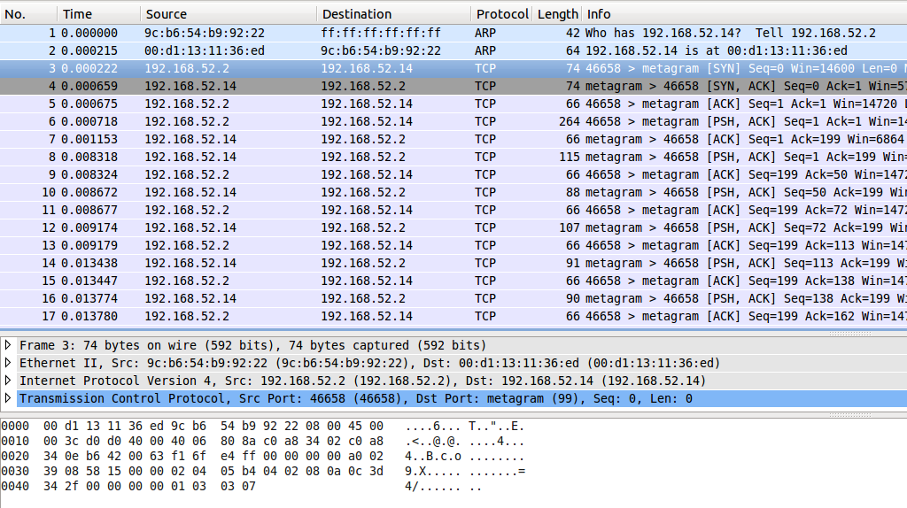

Ce qui est intéressant avec wireshark, c’est qu’il lui est possible de reconstituer l’échange en sélectionnant une trame puis en choississant **Follow TCP Stream** à partir du menu accessibe avec le bouton droit de la souris :

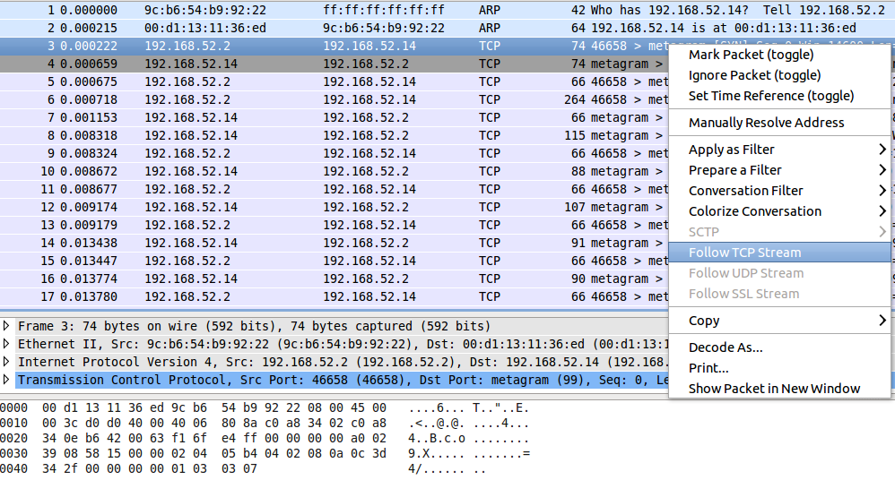

On obtient :

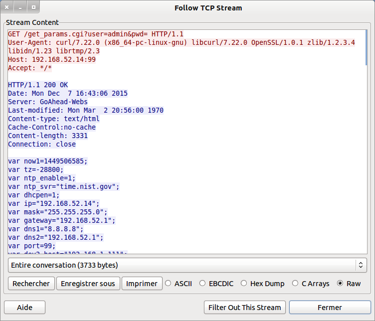

## Accès `telnet`

Pour accéder au serveur telnet de la caméra, il faut un compte. Ici, il apparait que le compte `root` n’est pas le même que celui pour administrer la caméra à partir de l’interface web (port 99). Obtenir le mot de pass de `root` sort du cadre de ce document. Mais on peut décrire la procédure si le système Linux est l’OS de la caméra :

- obtenir le *firmware* par le site du fabricant (c’est une habitude des constructeurs de le fournir car cela permet de mettre à jour le “logiciel” embarqué dans la caméra)
- analyser le *firmware* (un outil comme `binwalk` peut s’avérer utile)
- rechercher le fichier contenant le compte `root` et son mot de passe crypté (généralement un fichier `passwd` et éventuellement le fichier `shadow`)
- casser le mot de passe avec un logiciel comme *John the Ripper* (un outil comme `hydra` peut aussi être utilisé)

Pour ce type de caméra IP, le *firmware* est un fichier portant l’extension `.bin` :

```
// on recherche l'identifiant (PK) des fichiers ZIP
$ hexdump -n 160 -C 67.2.2.172.bin
00000000  77 69 66 69 2d 63 61 6d  65 72 61 2d 73 79 73 2d  |wifi-camera-sys-|
00000010  71 65 74 79 69 70 61 64  67 6a 6c 7a 63 62 6d 6e  |qetyipadgjlzcbmn|
00000020  25 0d 05 00 50 4b 03 04  0a 00 00 00 00 00 c2 99  |%...PK..........|
00000030  6c 43 00 00 00 00 00 00  00 00 00 00 00 00 07 00  |lC..............|
00000040  1c 00 73 79 73 74 65 6d  2f 55 54 09 00 03 7b 0d  |..system/UT...{.|
00000050  82 52 3d 12 7b 53 75 78  0b 00 01 04 fe ff 00 00  |.R=.{Sux........|
00000060  04 fe ff 00 00 50 4b 03  04 0a 00 00 00 00 00 c2  |.....PK.........|
00000070  99 6c 43 00 00 00 00 00  00 00 00 00 00 00 00 0b  |.lC.............|
00000080  00 1c 00 73 79 73 74 65  6d 2f 77 77 77 2f 55 54  |...system/www/UT|
00000090  09 00 03 7b 0d 82 52 3d  12 7b 53 75 78 0b 00 01  |...{..R=.{Sux...|
000000a0

// on renomme alors le fichier en .zip
$ mv 67.2.2.172.bin 67.2.2.172.zip

// on décompresse l'archive
$ unzip 67.2.2.172.zip
Archive:  67.2.2.172.zip
warning [67.2.2.172.zip]:  36 extra bytes at beginning or within zipfile
  (attempting to process anyway)
   creating: system/
   creating: system/www/
   creating: system/system/
   creating: system/system/bin/
  inflating: system/system/bin/daemon.v5.9
  inflating: system/system/bin/encoder
  inflating: system/system/bin/gmail_thread
   creating: system/system/lib/
   creating: system/system/drivers/
   creating: system/Wireless/
   creating: system/init/
  inflating: system/init/ipcam.sh

// on recherche le fichier passwd (et éventuellement shadow)
$ strings system/system/bin/daemon.v5.9 | grep -A 1 -B 1 passwd
/system/system/bin/encoder &
/etc/passwd
root:LSiuY7pOmZG2s:0:0:Adminstrator:/:/bin/sh
--
recive failed by zqh errno=%d
user or passwd is error
rm -f /tmp/post1.bin
check user or passwd is ok
GCC: (GNU) 3.3.2

// on peut rechercher si il y a des décompressions (avec unzip) avec mot de passe
$ strings system/system/bin/daemon.v5.9 | grep -A 1 -B 1 unzip
cp /tmp/system-b.ini /system/www/system-b.ini
unzip1 -o -P vstarcam!@#$%  /tmp/www.zip -d /system
rm /tmp/www.zip
--
First Extract all file Except daemon
unzip -o /tmp/system.zip -x system/system/bin/daemon* -d /.
Sencond Extract daemon only
unzip -o /tmp/system.zip system/system/bin/daemon* -d /.
chmod a+x /system/system/bin/*

// il faut donc décrypter la chaîne LSiuY7pOmZG2s (cf. John the Ripper)
// on obtient le mot de passe "123456"

// vérifions le mot de passe obtenu
$ perl -e "print crypt('123456','LS');"
LSiuY7pOmZG2s
```

```
John the Ripper (ou JTR, ou John) est un logiciel libre de cassage de mot de passe, utilisé notamment pour tester la sécurité d'un mot de passe (audit, crack). D'abord développé pour tourner sous les systèmes dérivés d'UNIX, le programme fonctionne aujourd'hui sous une cinquantaine de plates-formes différentes, telles que BeOS, BSD et ses dérivés, DOS, Linux, OpenVMS, Win32 ... John est l'un des craqueurs de mots de passe les plus populaires, car il inclut l'autodétection des tables de hachage utilisées par les mots de passe, l'implémentation d'un grand nombre d’algorithmes de cassage, par le fait qu'il soit très facilement modifiable, et aussi qu'il soit possible de reprendre une attaque après une pause (arrêt de la machine).
```

```
Ici, le mot de passe par défaut du compte root est 123456 !
```

```
$ telnet 192.168.52.216
Trying 192.168.52.216...
Connected to 192.168.52.216.
Escape character is '^]'.

(none) login: root
Password: 123456

BusyBox v1.12.1 (2012-11-20 15:16:24 CST) built-in shell (ash)
Enter 'help' for a list of built-in commands.

# ls
var     usr     tmp     system  sys     sbin    proc    param   mnt     media   lib
init    home    etc_ro  etc     dev     bin

# ifconfig
eth2      Link encap:Ethernet  HWaddr 00:D1:13:11:36:ED
...
```

```
BusyBox est un logiciel qui implémente un grand nombre des commandes standard sous Unix, à l'instar des GNU Core Utilities. Comme chaque fichier binaire exécutable pour Linux comporte plusieurs kilooctets d'informations additionnelles, l'idée de combiner plus de deux cent programmes en un seul fichier exécutable permet de gagner une taille considérable. Distribué sous la licence GNU GPL version 2, BusyBox est un logiciel libre.
```

Pour connaître l’architecture processeur de la caméra IP, on peut faire :

```
# cat proc/cpuinfo
system type             : Ralink SoC
processor               : 0
cpu model               : MIPS 24K V4.12
BogoMIPS                : 239.10
...

# free
              total         used         free       shared      buffers
  Mem:        29336        21940         7396            0         1012
 Swap:            0            0            0
Total:        29336        21940         7396
```

Et pour son système d’exploitation :

```
# cat proc/version
Linux version 2.6.21 (root@mailzxh-desktop) (gcc version 3.4.2) #653 Tue Nov 20 15:22:24 CST 2012
```

```
Sur les systèmes du type Unix/Linux, procfs (process file system, système de fichiers processus) est un pseudo-système de fichiers (pseudo car dynamiquement généré au démarrage) utilisé pour accéder aux informations du noyau sur les processus. Le système de fichiers est souvent monté sur le répertoire `/proc`. Puisque `/proc` n'est pas une arborescence réelle, il ne consomme aucun espace disque mais seulement une quantité limitée de mémoire vive. Une modification d'un fichier situé dans `/proc` ne sera donc pas permanente. Certains fichiers ne sont accessibles qu'en lecture seule.
```

```
Conclusion : la caméra est équipée d'un processeur Ralink MIPS CPU à 360Mhz, avec 32MB de RAM, et d'un système d'exploitation Linux 2.6.21.
```

On termine notre petit tour par une observation des serveurs actifs :

```
# netstat -nap
Active Internet connections (servers and established)
Proto Recv-Q Send-Q Local Address           Foreign Address         State       PID/Program name
tcp        0      0 0.0.0.0:99              0.0.0.0:*               LISTEN      147/encoder
tcp        0      0 0.0.0.0:23              0.0.0.0:*               LISTEN      28/telnetd
tcp        0      0 0.0.0.0:8600            0.0.0.0:*               LISTEN      29/daemon.v5.5
tcp        0      0 192.168.52.14:23        192.168.52.2:43586      ESTABLISHED 28/telnetd
udp      472      0 127.0.0.1:8832          0.0.0.0:*                           147/encoder
udp        0      0 127.0.0.1:6666          0.0.0.0:*                           147/encoder
udp        0      0 0.0.0.0:8600            0.0.0.0:*                           29/daemon.v5.5
udp        0      0 127.0.0.1:9123          0.0.0.0:*                           29/daemon.v5.5
udp        0      0 127.0.0.1:9124          0.0.0.0:*                           147/encoder
udp        0      0 0.0.0.0:32108           0.0.0.0:*                           147/encoder
udp        0      0 127.0.0.1:8812          0.0.0.0:*                           31/gmail_thread
udp        0      0 127.0.0.1:8813          0.0.0.0:*                           147/encoder
udp        0      0 127.0.0.1:8822          0.0.0.0:*                           147/encoder
udp        0      0 0.0.0.0:20989           0.0.0.0:*                           147/encoder
udp        0      0 127.0.0.1:8831          0.0.0.0:*                           30/cmd_thread
```

On en déduit que :

- le serveur web (HTTP) est le processus `encoder` (!) sur le port 99
- le serveur telnet est `telnetd` sur le port 23
- et qu’il y a un serveur qui s’exécute sur le port 8600 (?)

Cela correspond évidemment à ce que l’on avait obtenu avec `nmap` côté client.

Lorsque le système d’exploitation de la caméra démarre à la mise sous tension, celui-ci exécutera un script qui lance les serveurs identifiés précedemment :

```
// Que se passe-t-il au démarrage ?
# cat etc_ro/inittab
::sysinit:/etc_ro/rcS
ttyS1::respawn:/bin/sh

// on lance le script rc suivant :
# cat etc_ro/rcS
#!/bin/sh
mount -a
mkdir -p /var/run
cat /etc_ro/motd
nvram_daemon&
#goahead&
#for telnet debugging
#telnetd
#for syslogd
#/usr/sbin/network.sh
mkdir -p /var/log
mount -t jffs2 /dev/mtdblock6 /system
mount -t jffs2 /dev/mtdblock7 /param
/system/init/ipcam.sh

// qui se termine par l'exécution du script :
# cat system/init/ipcam.sh
export LD_LIBRARY_PATH=/system/system/lib:$LD_LIBRARY_PATH
export PATH=/system/system/bin:$PATH
telnetd
/system/system/bin/daemon.v5.5 &
/system/system/bin/cmd_thread &
/system/system/bin/gmail_thread &
```

```
Ne surtout pas modifier le mot de passe de root et le script ipcam.sh.
```

Le contrôle d’accès des pages web est réalisé à partir du fichier `login.cgi` :

```
# cat param/login.cgi
var loginuser="admin";
var loginpass="";
var pri=255;
```

Mais ce fichier est ré-écrit par le processus `encoder` (le serveur web) à partir du fichier `system.ini` qui contient la configuration réalisée par l’interface web. Ce fichier est un format binaire propre à l’application `encoder` contenant des chaînes des caractères dont le compte et mot de passe de l’administrateur.

On va afficher le contenu du fichier `system.ini` :

```
# cd /system/www/

# vi lire.sh
#!/bin/sh

# affiche un caractere visible
chr(){
    n=`expr "$1" : '[[:print:]]*'`
    if [ "$n" -eq 0 ]
    then
       # on remplace par le caractere %
       echo -n '%'
       return 1
    fi
    echo -n $1
}

# enleve les caracteres de controle
#cat "$1" | sed -e 's/[[:cntrl:]]/ /g' > ".$1"
cat "$1" > ".$1"

# affiche le fichier comme la commande strings
for ligne in $(cat ".$1");
do
   len=${#ligne}
   let i=0
   while [ $i -lt $len ]
   do
      a=${ligne:$i:1}
      chr $a
      let i=i+1
   done
   echo ""
done

rm -f ".$1"

# ./lire.sh system.ini
JWEV-182544-CFCFFIPCAM%%%C00:D1:13:11:36:ED%%00:D1:13:11:36:EE%%yHV%%%%%time.nist.gov
http://ipcpnp.com/upgengxin.aspP%P%192.168.52.216255.255.255.0192.168.52.18.8.8.8192.168.52.1%c
%%admin%%wanscam_office88888888%PIPCAM0123456789192.168.9.1255.255.255.0192.168.9.2192.168.9.254
%%%<%%%%%%%%%@P%%%
%@%%192.168.1.111IPCAMipcc
```

```
Ici, le compte administrateur de l'interface web est admin sans mot de passe.
```

Les fichiers composant l’interface web sont stockés à la racine du serveur HTTP :

```
# ls -l system/www/
system/www/Japanese/             system/www/codebase/             system/www/italian/
system/www/public.js             system/www/spanish/              system/www/Korean/
system/www/config.htm            system/www/jquery-1.3.1.js       system/www/reboot.htm
system/www/status.htm            system/www/Polski/               system/www/control.htm
system/www/jquery/               system/www/rebootme.htm          system/www/style.css
system/www/Portugal/             system/www/datetime.htm          system/www/live.htm
system/www/recordpath.htm        system/www/swedish/              system/www/Russian/
system/www/ddns.htm              system/www/log.htm               system/www/recordpath2.htm
system/www/system-b.ini          system/www/admin.htm             system/www/decoder.htm
system/www/login.htm             system/www/recordplay.htm        system/www/system.ini
...
```

Pour éditer un fichier, on peut évidemment utiliser le célèbre `vi` (voilà à quoi il sert !) :

```
# vi system/www/index.htm :
```

On constate qu’il existe une variable `language` qui permet de sélectionner la langue par défaut pour l’interface web (la valeur 3 correspond au français).

Pour sortir d’une session telnet, il suffit de faire :

```
# exit
```

Il est évidemment possible de *sniffer* le trafic de la communication `telnet` pour vérifier si l’authentification (*login/password*) est transmise en clair ou sous une forme cryptée.

Pour cela, vous pouvez utiliser **Wireshark** (en appliquant la règle de filtrage `tcp.port == 23`) :

```
$ gksudo wireshark
```

Ou `tcpdump` en ligne de commandes :

```
$ sudo tcpdump -Av port 23
...
```

```
Conclure sur le niveau de sécurité de ce type de caméra.
```

Retour au sommaire